# Lab 4 Diversity

### Set up the environment

```r
library(dada2)
library(ggplot2)
library(vegan)
library(reshape2)

options(stringsAsFactors = F)
```

#### Functions

```r
###
#        Function phylotype_analysis             #
###

phylotype_analysis <- function(obj, tax) {
  #obj: microbiome object with at least 1 slot (data)
  #tax: a tax object (named list taxa as names values in the list are seq ids)
  obj.out <- NULL
  for (h in 1:length(tax)) {
    df <- NULL
    #print(h)#debugging
    for (i in 1:length(tax[[h]])) {
      #print(i)#debugging
      v1       <- obj$data[, unlist(tax[[h]][[i]])]
      v2       <- names(tax[[h]])[i]
      if (is.null(dim(v1))) {
        df[[v2]] <- v1
      } else{
        df[[v2]] <- rowSums(v1)
      }
    }
    obj.out[[names(tax)[h]]] <- as.data.frame(df)
  }
  return(obj.out)
}

make_taxa_df <- function(tax){

  kingdom.df <- replicate(length(unique(tax[, 2])), c())
  names(kingdom.df) <- unique(tax[, 2])
  phylum.df  <- replicate(length(unique(tax[, 3])), c())
  names(phylum.df) <- unique(tax[, 3])
  class.df   <- replicate(length(unique(tax[, 4])), c())
  names(class.df) <- unique(tax[, 4])
  order.df   <- replicate(length(unique(tax[, 5])), c())
  names(order.df) <- unique(tax[, 5])
  family.df  <- replicate(length(unique(tax[, 6])), c())
  names(family.df) <- unique(tax[, 6])
  genus.df   <- replicate(length(unique(tax[, 7])), c())
  names(genus.df) <- unique(tax[, 7])

  for (i in 1:nrow(tax)) {
    kingdom.df[[tax[i, 2]]] <-
      c(kingdom.df[[tax[i, 2]]], tax[i, 1])
    phylum.df[[tax[i, 3]]]  <-
      c(phylum.df[[tax[i, 3]]], tax[i, 1])
    class.df[[tax[i, 4]]]   <-
      c(class.df[[tax[i, 4]]], tax[i, 1])
    order.df[[tax[i, 5]]]   <-
      c(order.df[[tax[i, 5]]], tax[i, 1])
    family.df[[tax[i, 6]]]  <-
      c(family.df[[tax[i, 6]]], tax[i, 1])
    genus.df[[tax[i, 7]]]   <-
      c(genus.df[[tax[i, 7]]], tax[i, 1])
  }

  tax.obj <- NULL
  tax.obj$kingdom <- kingdom.df
  tax.obj$phylum  <- phylum.df
  tax.obj$class   <- class.df
  tax.obj$order   <- order.df
  tax.obj$family  <- family.df
  tax.obj$genus   <- genus.df

  return(tax.obj)
}
```

### Import data

First we need to import the data that we generated before.

```r
all(rownames(metadata) == rownames(seqtab.nochim))
```

```
[1] TRUE
```

### Normalize

Next we will generate data normalized three ways. First rarefied, then relative abundance, then center log ratio transformed.

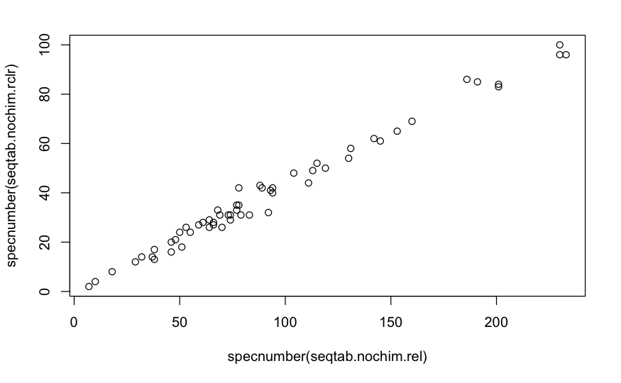

In practice we would choose one (perhaps two) methods of normalization. For illustration purpose only we can compare the number of asvs in each data set.

```r
cor.test(specnumber(seqtab.nochim.rare), specnumber(seqtab.nochim.rel) )
plot(specnumber(seqtab.nochim.rare), specnumber(seqtab.nochim.rel) )

cor.test(specnumber(seqtab.nochim.rare), specnumber(seqtab.nochim.rclr) )
plot(specnumber(seqtab.nochim.rare), specnumber(seqtab.nochim.rclr) )

cor.test(specnumber(seqtab.nochim.rel), specnumber(seqtab.nochim.rclr) )
plot(specnumber(seqtab.nochim.rel), specnumber(seqtab.nochim.rclr) )
```

[output not shown]

Now, reviewer 3 suggested that we lost 80% of our data given our subsampling thresholds. But that always seemed a little off to me, so just to twist the knife, lets look at the actual data lost during rarefaction. First, we will calculate total number of ASVs we lose the number of the samples filtered ASVs occur in.

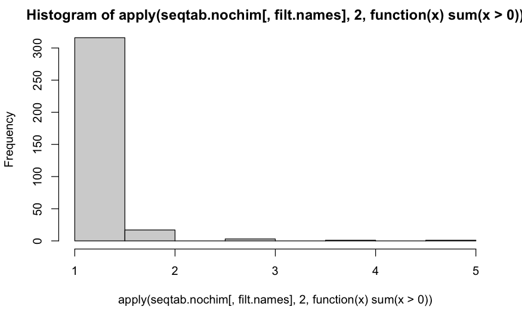

Above we found that the vast majority of ASVs that are filtered would be found in only one sample. Now we want to see the total abundance accross all samples (raw counts)

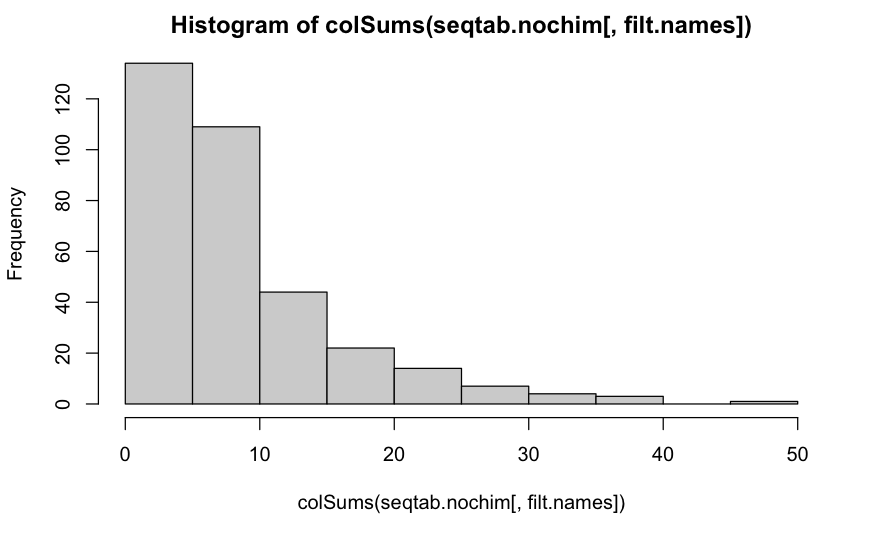

```r
#% total loss
sum(seqtab.nochim[,filt.names])/sum(seqtab.nochim)
```

```
[1] 0.002940718
```

So here we lost less than 1% of all abundance in the data frame. It is true that we filtered ~87% of data here, but since it is randomly subsampled without replacement, the new profiles will reflect the abundance in the data sets filtered with other methods. All that said its sometimes just a little easier to go along with the zealots.